# Solving ThreeME with thortwo

Building a model from a text file, solving it, and reloading it later

```r
library(thortwo)
library(dplyr)
library(tidyr)
library(purrr)
library(ggplot2)
```

**NoteA note on dependencies**

`thortwo` itself depends on no part of the tidyverse — deliberately, since the solver has no use for it. `dplyr`, `tidyr`, `purrr` and `ggplot2` are used *in this document* to handle and show results, which is how you would work with them in practice.

## What we are doing

Two workflows, end to end:

1. **Build and solve.** Read a ThreeME model from its `.txt` file, build it, load the data, solve it over a projection horizon, and check the answer.
2. **Reload.** Save the built model, and pick it up again in a later session without paying for the build a second time.

ThreeME at the 4x4 classification is 1729 equations. Everything below runs in well under a minute on a laptop.

```r
model_file <- system.file("ThreeME", "threeme_4x4_thor.txt", package = "thortwo")
data_file  <- system.file("ThreeME", "data3me_4x4.rds",      package = "thortwo")

c(model = basename(model_file), data = basename(data_file))
```

```
#>                  model                   data
#> "threeme_4x4_thor.txt"      "data3me_4x4.rds"
```

## 1. The model file

A model file is four sections: the endogenous variables, the exogenous variables, the coefficients, and the equations. Section headers are what identify them, so blank lines and separator banners are free — you cannot break the file by adding a line in the wrong place.

```r
writeLines(substr(head(readLines(model_file), 11), 1, 78))
```

```
#> endogenous variables :
#> ac_toe_cenj,ac_toe_cenj_senj,bal_g_prim_val,bal_g_prim_valbis,bal_g_tot_val,ba
#>  ##############
#> exogenous variables :
#> ac_toe_cenj_sser,adjust_ia_ia1_senj,adjust_ia_ia1_sind,adjust_ia_ia1_sser,adju
#>  ##############
#> coefficients :
#> elem_chd_cenj_chm_cenj_2015,elem_chd_cind_chm_cind_2015,elem_chd_cser_chm_cser
#>  ##############
#> equations :
#> t2val_y_pfc=(0+t2val_y_pfc_sind+t2val_y_pfc_strp+t2val_y_pfc_sser+t2val_y_pfc_
```

You can read those sections without building anything, which is the quickest way to check that a file is well formed:

```r
parts <- read_model_source(model_file)

tibble(
  section = names(parts),
  n       = lengths(parts)
)
```

| section | n |
| --- | --- |
| endogenous | 1729 |
| exogenous | 824 |
| coefficients | 129 |
| equations | 1729 |

An equation is written in the obvious way, optionally with a name in front of a colon. `lag(x, n)` and `delta(n, x)` are understood, along with the usual mathematical functions:

```r
writeLines(substr(parts$equations[1:4], 1, 78))
```

```
#> t2val_y_pfc=(0+t2val_y_pfc_sind+t2val_y_pfc_strp+t2val_y_pfc_sser+t2val_y_pfc_
#> rbal_g_prim_val=bal_g_prim_val/(pgdp*gdp)
#> ems_mat_n2o=(0+ems_mat_n2o_sind+ems_mat_n2o_sser+ems_mat_n2o_senj)
#> cim_cenj_senj=phi_cim_cenj_senj*ci_cenj_senj
```

## 2. Building the model

`thor_model()` does the whole pipeline: check, decompose into blocks, differentiate symbolically, generate a solver, compile it.

```r
t_build <- system.time(
  m <- thor_model("threeme4x4", model_file, backend = "sparse", verbose = FALSE,
                  recompile = TRUE)
)

m
```

```
#> <thor_model> 'threeme4x4'  [sparse]
#>   1729 equations, 1729 endogenous, 824 exogenous, 129 coefficients
#>   prologue    121 equations   jacobian 165 non-zero (1.13% dense)
#>   heart      1107 equations   jacobian 4168 non-zero (0.34% dense)
#>   epilogue    501 equations   jacobian 1024 non-zero (0.41% dense)
#>   generated C++: 411 KB, hash 46b3b9e076
#>   built 2026-10-05 08:25:51 with thortwo 0.1.0
```

`recompile = TRUE` is there only so that this page shows a real build every time it is rendered. Without it, `thor_model()` recognises a model it has already built and loads it from its cache instead, in about half a second, with a message saying so (see the cache below).

```r
cat("built in", round(t_build[["elapsed"]], 1), "s\n")
```

```
#> built in 9.3 s
```

### What the decomposition bought

The model is split into three blocks that are solved in sequence rather than all at once. Newton’s cost is cubic in block size, so this matters a great deal: only the *heart* is a genuinely simultaneous system.

```r
tibble(
  block            = names(m@blocks),
  equations        = map_int(m@blocks,   ~ length(.x$equations)),
  jacobian_entries = map_int(m@jacobian, ~ length(.x$i))
) |>
  mutate(pct_dense = round(100 * jacobian_entries / equations^2, 3))
```

| block | equations | jacobian_entries | pct_dense |
| --- | --- | --- | --- |
| prologue | 121 | 165 | 1.127 |
| heart | 1107 | 4168 | 0.340 |
| epilogue | 501 | 1024 | 0.408 |

### Choosing a backend

`backend` is stored on the model, and `thor_solve()` dispatches on it, so there is only ever one way to solve.

| backend | jacobian | needs a compiler | use it when |
| --- | --- | --- | --- |
| `"sparse"` | triplets, Eigen `SparseLU` | yes | the default: the fastest solve |
| `"sparse-r"` | triplets, `Matrix` sparse LU, pure R | no | no toolchain, or one quick run |
| `"dense-cpp"` | dense, Eigen `PartialPivLU` | yes | a cross-check of `"sparse"` |

All three produce the same answer — on Opale they agree to a median relative difference of about 1e-15 — but on ThreeME 4x4 the sparse solver is roughly 30x faster than the dense one, and at 8x8 it is 70x.

## 3. The data

One row per period, one column per variable, plus a column to use as the time index.

```r
data_3me <- readRDS(data_file)

cat(nrow(data_3me), "periods x", ncol(data_3me), "columns\n")
```

```
#> 54 periods x 3657 columns
```

```r
cat("years", min(data_3me$year), "to", max(data_3me$year), "\n")
```

```
#> years 2012 to 2065
```

```r
data_3me |> select(1:5) |> slice_head(n = 4)
```

| year | adjust2_py_sind | verif_mgsbis_ctrp | adjust_ycap_y_sind | es_mgpd_croa_crai_ctrp |
| --- | --- | --- | --- | --- |
| 2012 | 0.1 | 0 | 0 | 0.2 |
| 2013 | 0.1 | 0 | 0 | 0.2 |
| 2014 | 0.1 | 0 | 0 | 0.2 |
| 2015 | 0.1 | 0 | 0 | 0.2 |

Before solving, it is worth asking whether the database actually holds everything the model needs:

```r
data_model_checks(m, data_3me, quiet = FALSE)
```

```
#> All model variables are in the database.
#> [1] TRUE
```

If your coefficients live outside the database — as they do for Opale, in a separate two-column table — `add_coeffs()` broadcasts them on as constant columns first. ThreeME carries its own, so nothing to do here.

## 4. Solving

`thor_solve()` runs Newton per block, per period, starting each period from the previous one.

Two things to know about the period bounds. The first solved period cannot be the first row of the data: the solver needs a complete previous observation to initialise from and to supply the lagged terms. And every exogenous variable and coefficient must be present over the whole span — if one is missing, you get told which, rather than a convergence failure twenty periods later.

```r
res <- thor_solve(m, from = 2016, to = 2050,
                  data = data_3me, index_time = "year",
                  verbose = FALSE, diagnostics = TRUE)
```

`diagnostics = TRUE` attaches the per-period record:

```r
tibble(
  year        = as.integer(names(attr(res, "iterations"))),
  iterations  = as.integer(attr(res, "iterations")),
  scaled_step = signif(attr(res, "convergence"), 3),
  residual    = signif(attr(res, "residuals"), 3)
) |>
  slice_head(n = 8)
```

| year | iterations | scaled_step | residual |
| --- | --- | --- | --- |
| 2016 | 26 | 0.000823 | 0 |
| 2017 | 25 | 0.000469 | 0 |
| 2018 | 25 | 0.000811 | 0 |
| 2019 | 25 | 0.000694 | 0 |
| 2020 | 25 | 0.000760 | 0 |
| 2021 | 26 | 0.000338 | 0 |
| 2022 | 25 | 0.000867 | 0 |
| 2023 | 25 | 0.000934 | 0 |

```r
cat("solved", length(attr(res, "iterations")), "periods in",
    round(attr(res, "elapsed"), 3), "s\n")
```

```
#> solved 35 periods in 0.056 s
```

```r
cat("total Newton iterations:", sum(attr(res, "iterations")), "\n")
```

```
#> total Newton iterations: 896
```

```r
cat("worst scaled step:", signif(max(attr(res, "convergence")), 3),
    "(converges at 1)\n")
```

```
#> worst scaled step: 0.000935 (converges at 1)
```

The scaled step is a mixed criterion — a variable has converged when `|dx| <= rtol*|x| + atol` — reported normalised, so anything at or below 1 has converged. It is written that way because macro models mix variables of wildly different magnitude, and a great many of them sit at exactly zero in a given scenario.

### Checking the answer

Convergence is not the same as correctness. Newton will happily converge on whatever equations it was given; only the residuals notice if those are not the equations in your file. `model_residuals()` re-evaluates every equation at the solution:

```r
resid <- model_residuals(m, res, periods = 2016:2050, index_time = "year")

round(apply(resid, 2, max), 12)
```

```
#>  prologue     heart  epilogue
#> 0.000e+00 3.232e-09 1.925e-09
```

```r
stopifnot(max(resid) < 1e-6)
cat("max |residual| over all blocks and periods:", signif(max(resid), 3), "\n")
```

```
#> max |residual| over all blocks and periods: 3.23e-09
```

Make this check a habit. It is the one that catches code-generation bugs, and it costs milliseconds.

### Looking at the result

`res` is the input data frame with the endogenous variables filled in over the solved span; everything else is untouched.

```r
vars <- c("gdp", "pgdp", "unr", "ems_co2")

res |>
  filter(year %in% seq(2016, 2050, by = 5)) |>
  select(year, all_of(vars))
```

| year | gdp | pgdp | unr | ems_co2 |
| --- | --- | --- | --- | --- |
| 2016 | 2198447 | 1.020000 | 0.104 | 356.5525 |
| 2021 | 2328058 | 1.126162 | 0.104 | 377.5733 |
| 2026 | 2465310 | 1.243374 | 0.104 | 399.8334 |
| 2031 | 2610654 | 1.372786 | 0.104 | 423.4058 |
| 2036 | 2764566 | 1.515666 | 0.104 | 448.3679 |
| 2041 | 2927553 | 1.673418 | 0.104 | 474.8017 |
| 2046 | 3100148 | 1.847589 | 0.104 | 502.7939 |

## 5. Running a scenario

The usual reason to solve a model twice: change an exogenous input and compare. A scenario is an ordinary edit to the data frame — there is no separate shock machinery to learn. Here we raise the rate of social contributions by 10% from 2025 on.

```r
shock_var <- "rinc_soc_tax"

## It has to be exogenous: solving would simply overwrite an endogenous one.
stopifnot(shock_var %in% m@vars$exo)

## Flat across the baseline, so the shock below is a clean level change.
## (`unique()` would report 31 values here: they differ only in the last bit.)
summary(data_3me[[shock_var]])
```

```
#>    Min. 1st Qu.  Median    Mean 3rd Qu.    Max.     NAs
#>  0.1932  0.1932  0.1932  0.1932  0.1932  0.1932       1
```

```r
data_shock <- data_3me
rows <- data_shock$year >= 2025
data_shock[rows, shock_var] <- data_shock[rows, shock_var] * 1.10

res_shock <- thor_solve(m, 2016, 2050, data_shock, "year", verbose = FALSE)
```

Both runs used the same model object, so the comparison is like for like — only the input changed.

```r
reported <- c(gdp = "GDP", unr = "Unemployment rate", ems_co2 = "CO2 emissions")

compare <- bind_rows(
    baseline = res      |> select(year, all_of(names(reported))),
    scenario = res_shock |> select(year, all_of(names(reported))),
    .id = "run"
  ) |>
  pivot_longer(all_of(names(reported)), names_to = "variable", values_to = "value") |>
  pivot_wider(names_from = run, values_from = value) |>
  mutate(
    pct_diff = 100 * (scenario / baseline - 1),
    variable = factor(reported[variable], levels = unname(reported))
  ) |>
  ## Only the solved window is meaningful: outside it the two runs hold the
  ## same untouched data, so the difference is identically zero.
  filter(year >= 2016, year <= 2050)

compare |>
  filter(year %in% seq(2025, 2050, by = 5)) |>
  select(year, variable, pct_diff) |>
  pivot_wider(names_from = variable, values_from = pct_diff) |>
  mutate(across(-year, \(x) round(x, 3)))
```

| year | GDP | Unemployment rate | CO2 emissions |
| --- | --- | --- | --- |
| 2025 | -0.846 | 3.178 | -1.071 |
| 2030 | -1.654 | 11.305 | -2.350 |
| 2035 | -1.509 | 9.203 | -2.350 |
| 2040 | -1.406 | 7.712 | -2.297 |
| 2045 | -1.366 | 7.476 | -2.230 |
| 2050 | -1.345 | 7.618 | -2.159 |

All three series are in the same unit — percent deviation from baseline — so they belong on one axis. (Two measures of *different* scale would need two charts, or indexing to a common base; never a second y-axis.)

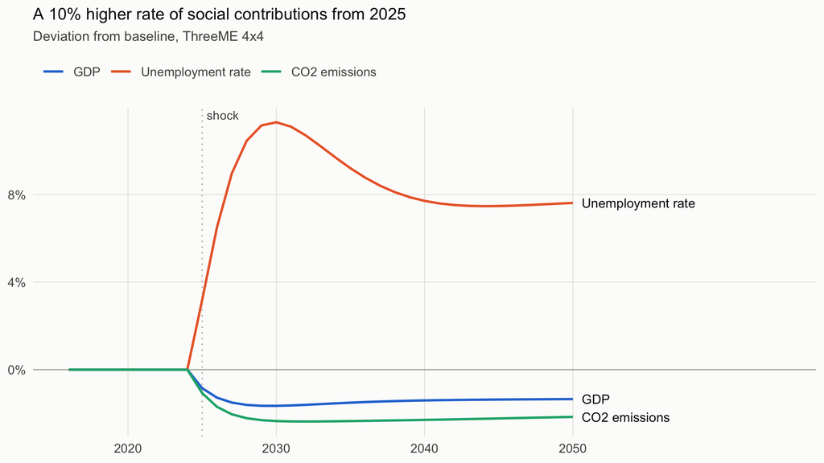

```r
## Categorical palette slots 1-3, validated for colour-vision deficiency
## separation against the light chart surface.
series_colours <- c("GDP"               = "#2a78d6",
                    "Unemployment rate" = "#eb6834",
                    "CO2 emissions"     = "#1baf7a")

ends <- compare |> filter(year == max(year))

ggplot(compare, aes(year, pct_diff, colour = variable)) +
  geom_hline(yintercept = 0, linewidth = 0.4, colour = "#b5b3ad") +
  geom_vline(xintercept = 2025, linewidth = 0.4, linetype = "dotted",
             colour = "#b5b3ad") +
  geom_line(linewidth = 0.8) +
  ## Direct labels as well as the legend, so identity is never colour alone.
  ## The label text wears ink rather than the series colour: the line it sits
  ## against carries the identity, and coloured text would be the harder read.
  geom_text(data = ends, aes(label = variable), hjust = 0, nudge_x = 0.6,
            size = 3.2, colour = "#0b0b0b", show.legend = FALSE) +
  annotate("text", x = 2025, y = Inf, label = "shock", vjust = 1.4, hjust = -0.15,
           size = 3, colour = "#52514e") +
  scale_colour_manual(values = series_colours, name = NULL) +
  scale_x_continuous(limits = c(2016, 2064), breaks = seq(2020, 2050, 10)) +
  scale_y_continuous(labels = scales::label_number(suffix = "%")) +
  labs(title = "A 10% higher rate of social contributions from 2025",
       subtitle = "Deviation from baseline, ThreeME 4x4",
       x = NULL, y = NULL) +
  theme_minimal(base_size = 11) +
  theme(
    plot.background   = element_rect(fill = "#fcfcfb", colour = NA),
    panel.background  = element_rect(fill = "#fcfcfb", colour = NA),
    panel.grid.minor  = element_blank(),
    panel.grid.major  = element_line(colour = "#e8e7e1", linewidth = 0.3),
    plot.title        = element_text(size = 11.5, colour = "#0b0b0b"),
    plot.subtitle     = element_text(size = 9.5,  colour = "#52514e"),
    axis.text         = element_text(colour = "#52514e"),
    legend.position   = "top",
    legend.justification = "left",
    legend.text       = element_text(colour = "#52514e")
  )
```

## 6. Saving and reloading a model

Building costs seconds to minutes. Solving costs milliseconds. So you build once and reload after that.

A saved model is **self-contained**: the `.rds` carries the generated solver source inside it, not a path to it. You can copy the file to another machine, commit it, or come back to it after a reboot has cleared `/tmp`, and it will still work.

```r
store <- file.path(tempdir(), "threeme4x4.rds")   # somewhere durable, in practice
thor_save(m, store)

cat("saved", round(file.size(store) / 1024^2, 1), "MB\n")
```

```
#> saved 0.3 MB
```

### In a later session

```r
t_load <- system.time(
  m2 <- thor_load(store)
)

m2
```

```
#> <thor_model> 'threeme4x4'  [sparse]
#>   1729 equations, 1729 endogenous, 824 exogenous, 129 coefficients
#>   prologue    121 equations   jacobian 165 non-zero (1.13% dense)
#>   heart      1107 equations   jacobian 4168 non-zero (0.34% dense)
#>   epilogue    501 equations   jacobian 1024 non-zero (0.41% dense)
#>   generated C++: 411 KB, hash 46b3b9e076
#>   built 2026-10-05 08:25:51 with thortwo 0.1.0
```

```r
cat("loaded and ready in", round(t_load[["elapsed"]], 2), "s\n")
```

```
#> loaded and ready in 0.02 s
```

That is the whole reload workflow — there is no separate “recompile” step to remember. `thor_load()` writes the stored source out and compiles it, which hits the compile cache whenever the code has not changed, so in practice it costs a fraction of a second. A model built here and a model loaded from disk are the same object:

```r
res2 <- thor_solve(m2, 2016, 2050, data_3me, "year", verbose = FALSE)

identical(res[, m@vars$endo], res2[, m2@vars$endo])
```

```
#> [1] TRUE
```

### The cache

The cache is what makes the above cheap, and it is on by default. It keeps two things: every **built model**, under a hash of its name, variables, equations and options, and its **compiled code**. So calling `thor_model()` again on a model whose equations have not changed, in this session or a later one, neither rebuilds nor recompiles it: it is loaded, and a message says so. `thor_model(..., recompile = TRUE)` forces a fresh build.

```r
thor_cache_dir()
```

```
#> [1] "/Users/139804/Library/Caches/org.R-project.R/R/thortwo/R-4.6.1"
```

```r
options(thortwo.cache.dir = "~/my-cache")   # move it
options(thortwo.cache.dir = FALSE)          # turn it off
clear_model_cache()                         # empty it
thor_model(..., cache = FALSE)              # or just for this build
options(thortwo.model.cache = FALSE)        # compile cache only: always rebuild the model
```

If you edit the model file, the generated code changes, the hash changes, and the next build recompiles by itself. You never have to remember to invalidate anything.

## 7. Where to go wrong

A few failure modes worth recognising:

**“The first period cannot be the first observation.”** The solver initialises from the previous row. Start at the second row or later.

**“Exogenous variables or coefficients are missing over the solved period.”** Exactly what it says, with the names listed. Extend your exogenous paths to cover the whole horizon.

**“Newton did not converge on block ‘heart’ at row N.”** The message reports the scaled step actually reached, the tolerance, and the worst residual. In order of likelihood: bad data at that period, an over-tight `rtol`, or a model that genuinely has no solution there. Try `max_iter = 200`, or look at the data for that year first.

**Converged, but the residuals are large.** That is a code-generation problem, not a numerical one. Report it — and it is why section 4 checks.

## Summary

```r
library(thortwo)

# once
m <- thor_model("mymodel", "mymodel.txt")
thor_save(m, "mymodel.rds")

# every time after that
m   <- thor_load("mymodel.rds")
res <- thor_solve(m, from = 2016, to = 2050, data = mydata, index_time = "year")
stopifnot(max(model_residuals(m, res, 2016:2050, "year")) < 1e-6)
```

```
#> thortwo 0.1.0 on R version 4.6.1 (2026-06-24)
```